# Project: Investigate a Dataset - tmbd-movies

- Introduction
- Data Wrangling
- Exploratory Data Analysis
- Conclusions

## Introduction

### Dataset Description

> The dataset contains movie records. These records contain adjusted revenue and budget set to the year 2010 for inflation.

### Question(s) for Analysis

> **Question 1:** Profitability vs popularity score - does the popularity score of the movie affect it's profit?

> **Question 2:** Popularity score vs runtime - Does the runtime affect the popularity of a movie?

> **Question 3:** Average profitability by genre - What genres are generally more profitable?

```python
# Setting up imports
import numpy as np
import pandas as pd
import matplotlib.pyplot as plt
```

#### Setting up library imports to use in the project.

## Data Wrangling

```python
#Read in and display the first few records for the movie dataset
df = pd.read_csv('Database_TMDb_movie_data/tmdb-movies.csv')
df.head()
```

|  | id | imdb_id | popularity | budget | revenue | original_title | cast | homepage | director | tagline | ... | overview | runtime | genres | production_companies | release_date | vote_count | vote_average | release_year | budget_adj | revenue_adj |
| --- | --- | --- | --- | --- | --- | --- | --- | --- | --- | --- | --- | --- | --- | --- | --- | --- | --- | --- | --- | --- | --- |
| 0 | 135397 | tt0369610 | 32.985763 | 150000000 | 1513528810 | Jurassic World | Chris Pratt\|Bryce Dallas Howard\|Irrfan Khan\|Vi... | http://www.jurassicworld.com/ | Colin Trevorrow | The park is open. | ... | Twenty-two years after the events of Jurassic ... | 124 | Action\|Adventure\|Science Fiction\|Thriller | Universal Studios\|Amblin Entertainment\|Legenda... | 6/9/15 | 5562 | 6.5 | 2015 | 1.379999e+08 | 1.392446e+09 |
| 1 | 76341 | tt1392190 | 28.419936 | 150000000 | 378436354 | Mad Max: Fury Road | Tom Hardy\|Charlize Theron\|Hugh Keays-Byrne\|Nic... | http://www.madmaxmovie.com/ | George Miller | What a Lovely Day. | ... | An apocalyptic story set in the furthest reach... | 120 | Action\|Adventure\|Science Fiction\|Thriller | Village Roadshow Pictures\|Kennedy Miller Produ... | 5/13/15 | 6185 | 7.1 | 2015 | 1.379999e+08 | 3.481613e+08 |
| 2 | 262500 | tt2908446 | 13.112507 | 110000000 | 295238201 | Insurgent | Shailene Woodley\|Theo James\|Kate Winslet\|Ansel... | http://www.thedivergentseries.movie/#insurgent | Robert Schwentke | One Choice Can Destroy You | ... | Beatrice Prior must confront her inner demons ... | 119 | Adventure\|Science Fiction\|Thriller | Summit Entertainment\|Mandeville Films\|Red Wago... | 3/18/15 | 2480 | 6.3 | 2015 | 1.012000e+08 | 2.716190e+08 |
| 3 | 140607 | tt2488496 | 11.173104 | 200000000 | 2068178225 | Star Wars: The Force Awakens | Harrison Ford\|Mark Hamill\|Carrie Fisher\|Adam D... | http://www.starwars.com/films/star-wars-episod... | J.J. Abrams | Every generation has a story. | ... | Thirty years after defeating the Galactic Empi... | 136 | Action\|Adventure\|Science Fiction\|Fantasy | Lucasfilm\|Truenorth Productions\|Bad Robot | 12/15/15 | 5292 | 7.5 | 2015 | 1.839999e+08 | 1.902723e+09 |
| 4 | 168259 | tt2820852 | 9.335014 | 190000000 | 1506249360 | Furious 7 | Vin Diesel\|Paul Walker\|Jason Statham\|Michelle ... | http://www.furious7.com/ | James Wan | Vengeance Hits Home | ... | Deckard Shaw seeks revenge against Dominic Tor... | 137 | Action\|Crime\|Thriller | Universal Pictures\|Original Film\|Media Rights ... | 4/1/15 | 2947 | 7.3 | 2015 | 1.747999e+08 | 1.385749e+09 |

5 rows × 21 columns

#### Reading in the dataset and displaying the firt handful of records.

```python
# Checking the columns
df.info()
```

```
<class 'pandas.core.frame.DataFrame'>
RangeIndex: 10866 entries, 0 to 10865
Data columns (total 21 columns):
 #   Column                Non-Null Count  Dtype
---  ------                --------------  -----
 0   id                    10866 non-null  int64
 1   imdb_id               10856 non-null  object
 2   popularity            10866 non-null  float64
 3   budget                10866 non-null  int64
 4   revenue               10866 non-null  int64
 5   original_title        10866 non-null  object
 6   cast                  10790 non-null  object
 7   homepage              2936 non-null   object
 8   director              10822 non-null  object
 9   tagline               8042 non-null   object
 10  keywords              9373 non-null   object
 11  overview              10862 non-null  object
 12  runtime               10866 non-null  int64
 13  genres                10843 non-null  object
 14  production_companies  9836 non-null   object
 15  release_date          10866 non-null  object
 16  vote_count            10866 non-null  int64
 17  vote_average          10866 non-null  float64
 18  release_year          10866 non-null  int64
 19  budget_adj            10866 non-null  float64
 20  revenue_adj           10866 non-null  float64
dtypes: float64(4), int64(6), object(11)
memory usage: 1.7+ MB
```

#### Checking out the dataset. Seeing columns, data types, and non-null counts.

### Data Cleaning

```python
# Check for and remove duplicates
print(f"Number of rows before duplicates removed: {len(df)}")
print(f"Number of duplicates found: {df.duplicated().sum()}")
print(f"Number of rows after duplicates removed: {len(df)}")
df.drop_duplicates(inplace=True)
```

```
Number of rows before duplicates removed: 10866
Number of duplicates found: 1
Number of rows after duplicates removed: 10866
```

#### Checked for any duplicate records. There was one duplicate before removing it.

```python
# Setting up proper date format on the release_date column

# Setting release_date to datetime
df['release_date'] = pd.to_datetime(df['release_date'])
# Pulling out the month and day
df['month'] = (df['release_date']).dt.month
df['day'] = (df['release_date']).dt.day
# Pulling the year from release year as datetime format will improperly format a year such as 66 to 2066 instead of 1966
df['year'] = df['release_year']
# Putting it all together
df['release_date'] = pd.to_datetime(df[['year','month','day']])

# Checking to make sure it's right
df.info()
print(min(df['release_date']),min(df['release_year']))
print(max(df['release_date']), max(df['release_year']))
```

```
<class 'pandas.core.frame.DataFrame'>
Int64Index: 10865 entries, 0 to 10865
Data columns (total 24 columns):
 #   Column                Non-Null Count  Dtype
---  ------                --------------  -----
 0   id                    10865 non-null  int64
 1   imdb_id               10855 non-null  object
 2   popularity            10865 non-null  float64
 3   budget                10865 non-null  int64
 4   revenue               10865 non-null  int64
 5   original_title        10865 non-null  object
 6   cast                  10789 non-null  object
 7   homepage              2936 non-null   object
 8   director              10821 non-null  object
 9   tagline               8041 non-null   object
```

[output cut: 18 more lines]

#### Formatted release_date to proper date format and checked to make sure max and min years line up.

```python
# Drop extra columns
# Date columns not needed after reformatting release_date
df.drop(columns = ['month', 'day', 'year', 'release_year'], inplace = True)
# Columns not needed
df.drop(columns = ['homepage', 'tagline', 'keywords', 'overview'], inplace = True)
df.info()
```

```
<class 'pandas.core.frame.DataFrame'>
Int64Index: 10865 entries, 0 to 10865
Data columns (total 16 columns):
 #   Column                Non-Null Count  Dtype
---  ------                --------------  -----
 0   id                    10865 non-null  int64
 1   imdb_id               10855 non-null  object
 2   popularity            10865 non-null  float64
 3   budget                10865 non-null  int64
 4   revenue               10865 non-null  int64
 5   original_title        10865 non-null  object
 6   cast                  10789 non-null  object
 7   director              10821 non-null  object
 8   runtime               10865 non-null  int64
 9   genres                10842 non-null  object
 10  production_companies  9835 non-null   object
 11  release_date          10865 non-null  datetime64[ns]
 12  vote_count            10865 non-null  int64
 13  vote_average          10865 non-null  float64
 14  budget_adj            10865 non-null  float64
 15  revenue_adj           10865 non-null  float64
dtypes: datetime64[ns](1), float64(4), int64(5), object(6)
memory usage: 1.4+ MB
```

#### Cleaning up some of the columns that won't be used.

```python
# Convert 0s in the adjusted budget and revenue columns to null for future deletion
df['budget_adj'].replace(0, np.nan, inplace=True)
df['revenue_adj'].replace(0, np.nan, inplace=True)
```

#### Setting to null instead of 0 to catch with future function of dropping nulls. These values are needed for profitability calculations and if they are missing, then they won't help.

```python
# Drop nulls
print(f"Before drop: {len(df)}")
df.dropna(inplace = True)
print(f"After drop: {len(df)}")
```

```
Before drop: 10865
After drop: 3805
```

#### Removing any records that have nulls.

```python
# Create profit column for future use
df['profit'] = df['revenue_adj'] - df['budget_adj']
```

#### Profit column will be used for future visualizations.

```python
# Set up a dataframe for genres
df_genres = df.assign(genres=df['genres'].str.split('|')).explode('genres')
print(len(df_genres))
```

```
10180
```

#### The genres column contained multiple genres for multiple movies. This separates it out for future use.

## Exploratory Data Analysis

> Analysis is of the subset of data that did not include nulls, which includes any records that showed 0 for adjusted budget or revenue. Going to look at profitability vs popularity score, popularity vs runtime, and profitability vs genre.

### Research Question 1 - Does popularity score affect profit? (adjusted revenue - adjusted budget)

```python
# Function to make scatter plots
def sc_plot(df, x_column, y_column, title, x_label, y_label):
    df.plot(kind = 'scatter', x = x_column, y = y_column)
    plt. title(title)
    plt.xlabel(x_label)
    plt.ylabel(y_label)
    plt.show()
```

#### Creating function to call for the next two scatter plots.

```python
# Function for correlation coefficient
def c_coef(x,y):
    print('Correlation Coefficient:\n')
    coef = df[[x,y]].corr()
    print(coef)
```

#### Function to calculate the correlation coefficient between x and y values.

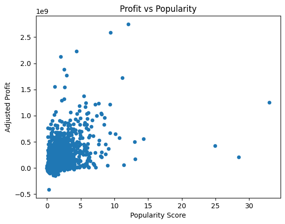

```python
# Plot popularity score and profit
sc_plot(df,'popularity','profit','Profit vs Popularity','Popularity Score','Adjusted Profit')
```

```python
# Profit and popularity score correlation score
c_coef('popularity','profit')
```

```
Correlation Coefficient:

            popularity    profit
popularity    1.000000  0.515125
profit        0.515125  1.000000
```

#### .515 indicates a moderate correlation between popularity score and profit, but it isn't the only driver.

### Research Question 2 - Does runtime affect the popularity score?

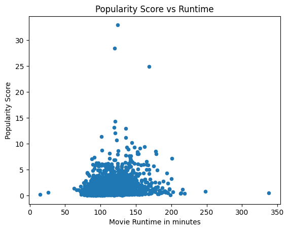

```python
# Plot runtime and popularity
sc_plot(df,'runtime','popularity','Popularity Score vs Runtime','Movie Runtime in minutes', 'Popularity Score')
```

```python
# Correlation coefficient for popularity vs runtime
c_coef('runtime','popularity')
```

```
Correlation Coefficient:

            runtime  popularity
runtime     1.00000     0.21369
popularity  0.21369     1.00000
```

### Research Question 3 - Profitability by genre?

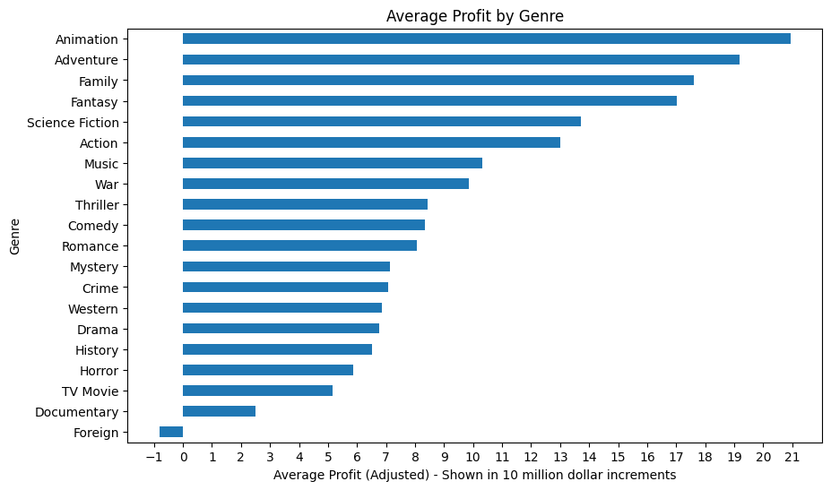

```python
# Using the df_genres dataframe to show average profit by genre
avg_profit_by_genre = df_genres.groupby('genres')['profit'].mean().sort_values(ascending=True)
# Dividing down for easier viewing - including in the chart label
avg_profit_by_genre = avg_profit_by_genre / 10000000
avg_profit_by_genre.plot(kind='barh', figsize=(10,6))
plt.title('Average Profit by Genre')
plt.xlabel('Average Profit (Adjusted) - Shown in 10 million dollar increments')
plt.ylabel('Genre')
plt.xticks(np.arange(-1, max(avg_profit_by_genre) + 1, 1))
plt.show()
```

#### Animation, adventure, and family genre movies are the most profitable genres. Other genres can be successful, but possibly due to other things such as budget have overall lower average profit.

```python
# Profitability rate by genre
df_genres['is_profitable'] = df_genres['profit'] > 0
profit_rate = df_genres.groupby('genres')['is_profitable'].mean().sort_values(ascending = False)
print(profit_rate.apply(lambda x: f'{x:.2%}'))
```

```
genres
TV Movie           100.00%
Documentary         84.62%
Animation           80.90%
Family              80.82%
Adventure           77.12%
Fantasy             74.94%
Comedy              74.83%
War                 74.79%
Horror              74.29%
Science Fiction     73.69%
Action              72.96%
History             72.66%
Music               71.76%
Crime               71.34%
Romance             70.97%
Thriller            70.02%
Drama               67.09%
Mystery             64.43%
Western             63.46%
Foreign             11.11%
Name: is_profitable, dtype: object
```

#### Shows overall profitability chance by genre. So some genres might not make much profit, but are still likely to profit.

## Conclusions

```python
# Running this cell will execute a bash command to convert this notebook to an .html file
!python -m nbconvert --to html Investigate_a_Dataset.ipynb
```

```
[NbConvertApp] Converting notebook Investigate_a_Dataset.ipynb to html
[NbConvertApp] WARNING | Alternative text is missing on 3 image(s).
[NbConvertApp] Writing 445795 bytes to Investigate_a_Dataset.html
```